# HW2

## Introduction This report is created according to the data from 1 July to 31 July [Energy Exchange Istanbul(EXIST) page](https://rapor.epias.com.tr/rapor/xhtml/ptfSmfListeleme.xhtml).

```r
setwd("C:/Users/ABDULLAH/Desktop")

library(readr)
library(tidyverse)
library(lubridate)
veri<- read.csv("HW.csv",stringsAsFactors = TRUE, header=TRUE)

str(veri)
```

```
## 'data.frame':    744 obs. of  6 variables:
##  $ Date                             : Factor w/ 744 levels "01.07.20 00:00",..: 1 2 3 4 5 6 7 8 9 10 ...
##  $ MCP                              : num  324 327 324 322 320 ...
##  $ SMP                              : num  211 201 211 211 201 ...
##  $ Positive.Imbalance.Price..TL.MWh.: num  205 195 205 205 195 ...
##  $ Negative.Imbalance.Price..TL.MWh.: num  334 337 334 332 330 ...
##  $ SMP.Direction                    : Factor w/ 3 levels "Energy Deficit",..: 2 2 2 2 2 2 2 2 2 2 ...
```

So as to see changes , I use Glimpse() function. I also edited some columns in excel before starting this report.

```r
veri %>% glimpse()
```

```
## Rows: 744
## Columns: 6
## $ Date                              <fct> 01.07.20 00:00, 01.07.20 01:00, 0...
## $ MCP                               <dbl> 323.85, 326.95, 324.31, 322.11, 3...
## $ SMP                               <dbl> 211.00, 201.00, 211.00, 211.00, 2...
## $ Positive.Imbalance.Price..TL.MWh. <dbl> 204.67, 194.97, 204.67, 204.67, 1...
## $ Negative.Imbalance.Price..TL.MWh. <dbl> 333.57, 336.76, 334.04, 331.77, 3...
## $ SMP.Direction                     <fct> Energy Surplus, Energy Surplus, E...
```

```r
data <- veri %>%
  rename(  d = Date, mcp = MCP, smp = SMP, pip = Positive.Imbalance.Price..TL.MWh., nip = Negative.Imbalance.Price..TL.MWh., sd = SMP.Direction)

data$d <- strptime(data$d,format="%d.%m.%y %H:%M")



data %>% glimpse()
```

```
## Rows: 744
## Columns: 6
## $ d   <dttm> 2020-07-01 00:00:00, 2020-07-01 01:00:00, 2020-07-01 02:00:00,...
## $ mcp <dbl> 323.85, 326.95, 324.31, 322.11, 320.00, 286.21, 210.13, 318.20,...
## $ smp <dbl> 211.00, 201.00, 211.00, 211.00, 201.00, 181.00, 113.75, 201.00,...
## $ pip <dbl> 204.67, 194.97, 204.67, 204.67, 194.97, 175.57, 110.34, 194.97,...
## $ nip <dbl> 333.57, 336.76, 334.04, 331.77, 329.60, 294.80, 216.43, 327.75,...
## $ sd  <fct> Energy Surplus, Energy Surplus, Energy Surplus, Energy Surplus,...
```

Some statistics like min, quartile , median and max can be seen below.

Also, It can be seen that SMP values are higher than MCP values. So, we can mention about energy deficit for those.

```r
data %>% summarise(count=n())
```

```
##   count
## 1   744
```

```r
data %>% filter(sd == "Energy Deficit") %>% summarise(count=n())
```

```
##   count
## 1   528
```

```r
data %>% filter(sd == "In Balance") %>% summarise(count=n())
```

```
##   count
## 1    21
```

```r
data %>% filter(sd == "Energy Surplus") %>% summarise(count=n())
```

```
##   count
## 1   195
```

```r
data %>% summary
```

```
##        d                            mcp             smp             pip
##  Min.   :2020-07-01 00:00:00   Min.   :140.0   Min.   : 10.0   Min.   :  9.7
##  1st Qu.:2020-07-08 17:45:00   1st Qu.:300.0   1st Qu.:250.0   1st Qu.:228.2
##  Median :2020-07-16 11:30:00   Median :306.6   Median :320.0   Median :293.4
##  Mean   :2020-07-16 11:30:00   Mean   :296.4   Mean   :299.3   Mean   :268.6
##  3rd Qu.:2020-07-24 05:15:00   3rd Qu.:317.0   3rd Qu.:345.0   3rd Qu.:304.1
##  Max.   :2020-07-31 23:00:00   Max.   :350.0   Max.   :460.0   Max.   :339.5
##       nip                     sd
##  Min.   :144.2   Energy Deficit:528
##  1st Qu.:312.9   Energy Surplus:195
##  Median :331.9   In Balance    : 21
##  Mean   :328.3
##  3rd Qu.:355.4
##  Max.   :473.8
```

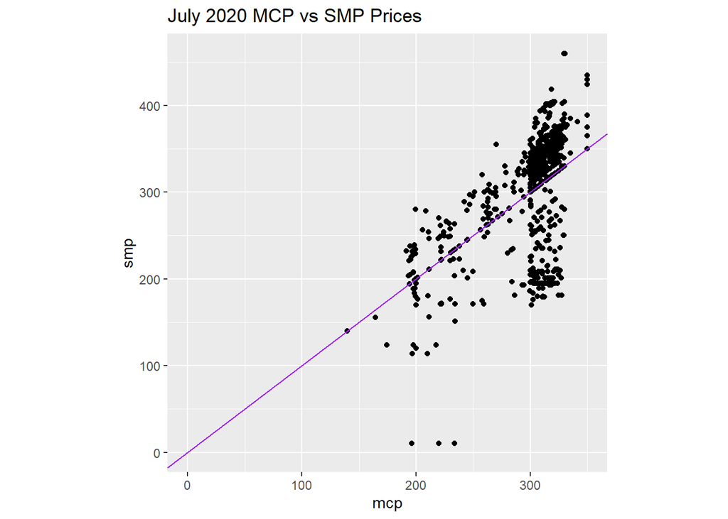

```r
ggplot(data, aes(x=mcp, y=smp)) + geom_point() + theme(aspect.ratio=1)+ xlim(0,350) + ylim(0,460) + ggtitle("July 2020 MCP vs SMP Prices  ") + labs(x = "mcp", y = "smp") + geom_abline(slope=1, intercept=0, color="purple")
```

In energy industry, data is collected as hourly. In this report, data is extracted from July 1 to July 31. The price changes regarding the hour of the day should be observed. In the graph, you can see relationship `MCP` vs. `hour_of_day` for same hours

It can be observed that there maybe a relationship between same hours of different days,

I also create second ggplot to calculate the hourly average values for each hour.

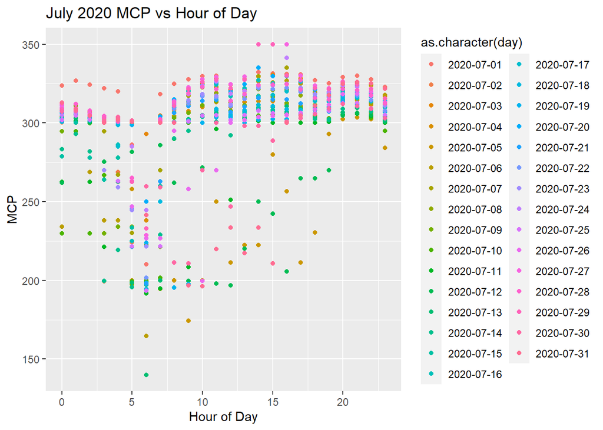

```r
plot_one <- data %>% group_by(hour_of_day = lubridate::hour(d), day=lubridate::date(d))
ggplot(plot_one, aes(x = hour_of_day, y = mcp, color=as.character(day))) + geom_point() + ggtitle("July 2020 MCP vs Hour of Day ") + labs(x="Hour of Day", y="MCP")
```

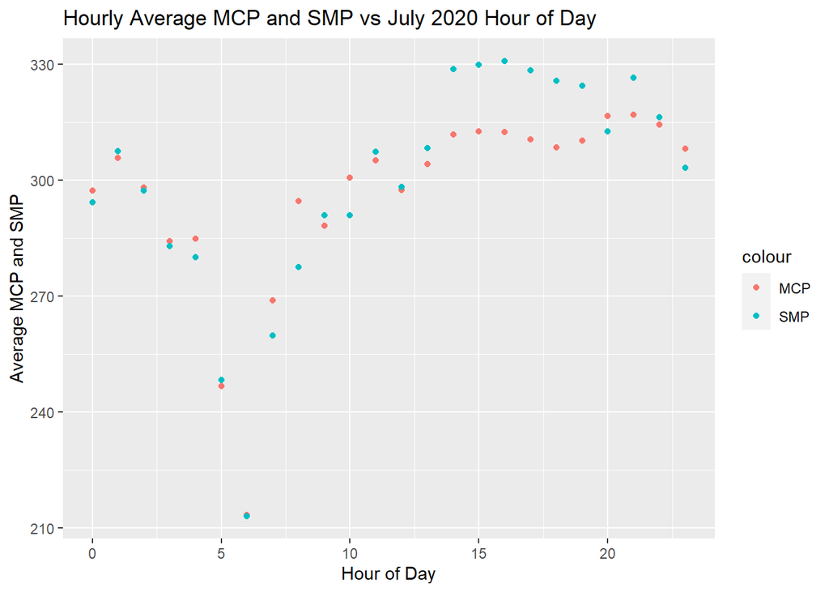

```r
plot_two<-data %>% group_by(hour_of_day = lubridate::hour(d)) %>% summarise(avg_MCP = mean(mcp), avg_SMP = mean(smp))
ggplot(plot_two) + geom_point(aes(x = hour_of_day, y = avg_MCP, color="MCP")) + geom_point(aes(x = hour_of_day, y = avg_SMP, color="SMP")) + ggtitle("Hourly Average MCP and SMP vs July 2020 Hour of Day") + labs(x="Hour of Day", y="Average MCP and SMP")
```

Here you can see average values of MCP and SMP

```r
plot_three <- data %>% group_by(day = lubridate::day(d)) %>% summarise(daily_avg_MCP= mean(mcp), daily_avg_SMP= mean(smp),daily_avg_pip=mean(pip),daily_avg_nip=mean(nip))
print(plot_three)
```

```
## # A tibble: 31 x 5
##      day daily_avg_MCP daily_avg_SMP daily_avg_pip daily_avg_nip
##    <int>         <dbl>         <dbl>         <dbl>         <dbl>
##  1     1          320.          268.          250.          341.
##  2     2          298.          357.          289.          368.
##  3     3          317.          373.          307.          384.
##  4     4          306.          321.          292.          336.
##  5     5          258.          198.          192.          265.
##  6     6          290.          307.          280.          317.
##  7     7          307.          298.          277.          330.
##  8     8          304.          191.          185.          313.
##  9     9          288.          189.          183.          297.
## 10    10          282.          292.          270.          305.
## # ... with 21 more rows
```

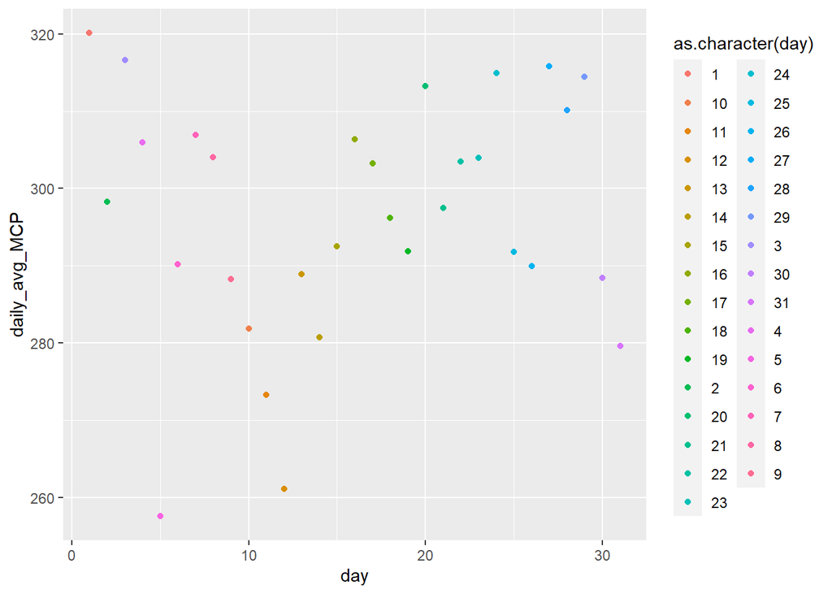

```r
ggplot(plot_three) + geom_point(aes(x = day, y = daily_avg_MCP, color=as.character(day)))
```

The first graph shows that MCP is getting higher after morning hour by hour.

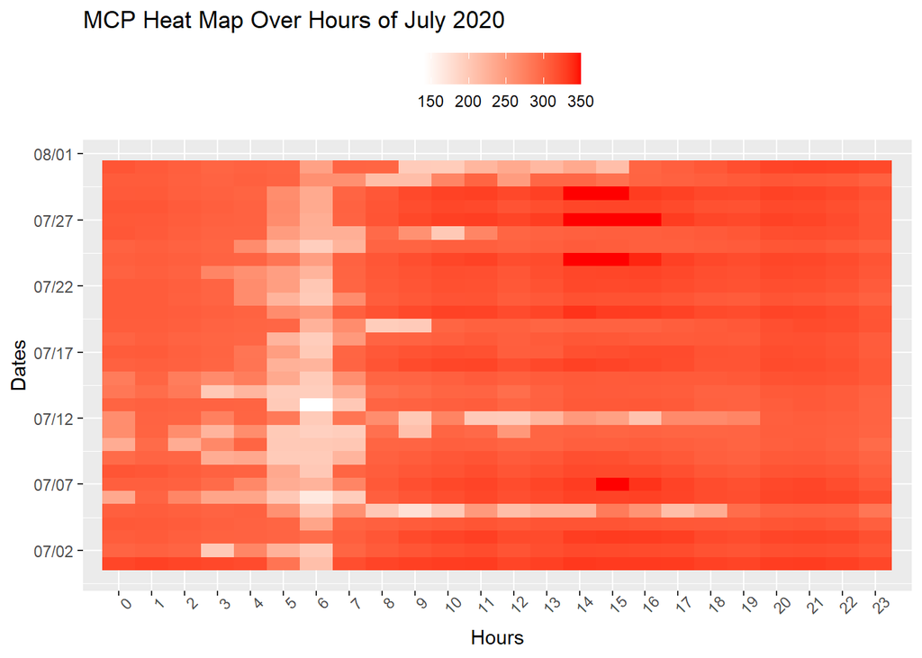

```r
plot_four <- data %>% group_by(hour_of_day = lubridate::hour(d), day=lubridate::date(d))
ggplot(plot_four, aes(x = hour_of_day, y = day, fill=mcp)) +
  geom_point() +
  ggtitle("MCP Heat Map Over Hours of July 2020") +
  geom_tile() +
  scale_fill_gradient(low="white", high="red") +
  labs(x = "Hours",
       y = "Dates") +
  scale_y_date(date_breaks = "5 day", date_labels = "%m/%d") +
  scale_x_discrete(limits=c(0:23)) +
  theme(axis.text.x = element_text(angle = 45), legend.position = "top",
        legend.title = element_blank())
```

```r
print(plot_four)
```

```
## # A tibble: 744 x 8
## # Groups:   hour_of_day, day [744]
##    d                     mcp   smp   pip   nip sd         hour_of_day day
##    <dttm>              <dbl> <dbl> <dbl> <dbl> <fct>            <int> <date>
##  1 2020-07-01 00:00:00  324.  211   205.  334. Energy Su~           0 2020-07-01
##  2 2020-07-01 01:00:00  327.  201   195.  337. Energy Su~           1 2020-07-01
##  3 2020-07-01 02:00:00  324.  211   205.  334. Energy Su~           2 2020-07-01
##  4 2020-07-01 03:00:00  322.  211   205.  332. Energy Su~           3 2020-07-01
##  5 2020-07-01 04:00:00  320   201   195.  330. Energy Su~           4 2020-07-01
##  6 2020-07-01 05:00:00  286.  181   176.  295. Energy Su~           5 2020-07-01
##  7 2020-07-01 06:00:00  210.  114.  110.  216. Energy Su~           6 2020-07-01
##  8 2020-07-01 07:00:00  318.  201   195.  328. Energy Su~           7 2020-07-01
##  9 2020-07-01 08:00:00  325.  181   176.  335. Energy Su~           8 2020-07-01
## 10 2020-07-01 09:00:00  328.  181   176.  338. Energy Su~           9 2020-07-01
## # ... with 734 more rows
```

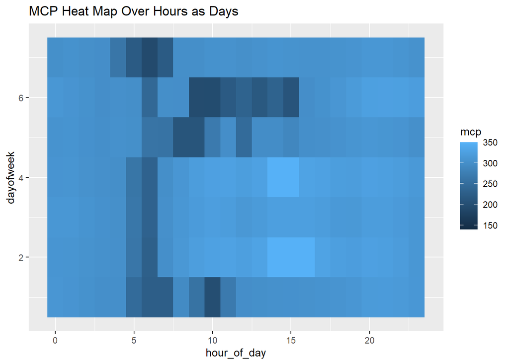

```r
plot_five <- data %>% group_by(hour_of_day = lubridate::hour(d), dayofweek = lubridate::wday(d))
ggplot(plot_five, aes(x = hour_of_day, y = dayofweek , fill=mcp)) +  ggtitle("MCP Heat Map Over Hours as Days") +

  geom_tile()
```

```r
print(plot_five)
```

```
## # A tibble: 744 x 8
## # Groups:   hour_of_day, dayofweek [168]
##    d                     mcp   smp   pip   nip sd          hour_of_day dayofweek
##    <dttm>              <dbl> <dbl> <dbl> <dbl> <fct>             <int>     <dbl>
##  1 2020-07-01 00:00:00  324.  211   205.  334. Energy Sur~           0         4
##  2 2020-07-01 01:00:00  327.  201   195.  337. Energy Sur~           1         4
##  3 2020-07-01 02:00:00  324.  211   205.  334. Energy Sur~           2         4
##  4 2020-07-01 03:00:00  322.  211   205.  332. Energy Sur~           3         4
##  5 2020-07-01 04:00:00  320   201   195.  330. Energy Sur~           4         4
##  6 2020-07-01 05:00:00  286.  181   176.  295. Energy Sur~           5         4
##  7 2020-07-01 06:00:00  210.  114.  110.  216. Energy Sur~           6         4
##  8 2020-07-01 07:00:00  318.  201   195.  328. Energy Sur~           7         4
##  9 2020-07-01 08:00:00  325.  181   176.  335. Energy Sur~           8         4
## 10 2020-07-01 09:00:00  328.  181   176.  338. Energy Sur~           9         4
## # ... with 734 more rows
```